# Barnacles SNP and DE

Eddy Dowle

3/7/2018

## Exploring SNP analyses with DE

Bring in DE file. This is just the DE genes

```r
library(dplyr)
```

```r
expressiondat<-read.csv("~/Documents/github/barnacles/annot.results.csv",header=T)
colnames(expressiondat)
```

```
##  [1] "X"                 "SeqName"           "number"
##  [4] "geneid"            "basemean"          "log2fc"
##  [7] "stderr"            "wald"              "pval"
## [10] "padj"              "group"             "group.BCT4_1"
## [13] "group.BCT4_2"      "group.BCT4_3"      "group.BCT4_4"
## [16] "group.BCT3_1"      "group.BCT3_2"      "group.BCT3_3"
## [19] "group.BCT3_4"      "group.BCT2_1"      "group.BCT2_2"
## [22] "group.BCT2_3"      "group.BCT2_4"      "group.BCT1_1"
## [25] "group.BCT1_2"      "group.BCT1_3"      "group.BCT1_4"
## [28] "group.WST4_1"      "group.WST4_2"      "group.WST4_3"
## [31] "group.WST4_4"      "group.WST3_1"      "group.WST3_2"
## [34] "group.WST3_3"      "group.WST3_4"      "group.WST2_1"
## [37] "group.WST2_2"      "group.WST2_3"      "group.WST2_4"
## [40] "group.WST1_1"      "group.WST1_2"      "group.WST1_3"
## [43] "group.WST1_4"      "Tags"              "Description"
## [46] "Length"            "X.Hits"            "e.Value"
## [49] "sim.mean"          "X.GO"              "GO.IDs"
## [52] "GO.Names"          "Enzyme.Codes"      "Enzyme.Names"
## [55] "InterPro.IDs"      "InterPro.GO.IDs"   "InterPro.GO.Names"
```

# Across all Differentially Expressed (DE) transcripts

Some of these are annotated as having two genes on the same scaffold Im just going to average by scafold ~not sure if that is the ‘right’ way to go about this

```r
dcorrected_BCT<-read.table("~/Documents/Barnacles/notreat/popoolation/barnacles.BCT.notreat.sort.gtf.min4max50000.downsample.dcorrected.clean",header=T)
dcorrected_WST<-read.table("~/Documents/Barnacles/notreat/popoolation/barnacles.WST.notreat.sort.gtf.min4max50000.downsample.dcorrected.clean",header=T)

dcorrected_BCT<-dcorrected_BCT %>% group_by(.,SeqName) %>% summarise(.,dcorrected_ave = mean(dcorrected, na.rm = T),snp_count=sum(number_snps))
dcorrected_WST<-dcorrected_WST %>% group_by(.,SeqName) %>% summarise(.,dcorrected_ave = mean(dcorrected, na.rm = T),snp_count=sum(number_snps))

#average tajima D within BCT that are DE
dcorrected_BCT %>% filter(., SeqName %in% expressiondat$SeqName) %>% ungroup() %>% select(.,dcorrected_ave) %>% colMeans()
```

```
## dcorrected_ave
##      -1.188611
```

```r
#average tajima D within BCT that are NOT DE
dcorrected_BCT %>% filter(., !SeqName %in% expressiondat$SeqName) %>% ungroup() %>% select(.,dcorrected_ave) %>% colMeans()
```

```
## dcorrected_ave
##     -0.6417929
```

```r
#average tajima D within WST that are DE
dcorrected_WST %>% filter(., SeqName %in% expressiondat$SeqName) %>% ungroup() %>% select(.,dcorrected_ave) %>% colMeans()
```

```
## dcorrected_ave
##      -1.422189
```

```r
#average tajima D within WST that are NOT DE
dcorrected_WST %>% filter(., !SeqName %in% expressiondat$SeqName) %>% ungroup() %>% select(.,dcorrected_ave) %>% colMeans()
```

```
## dcorrected_ave
##     -0.8071944
```

BCT: t-test

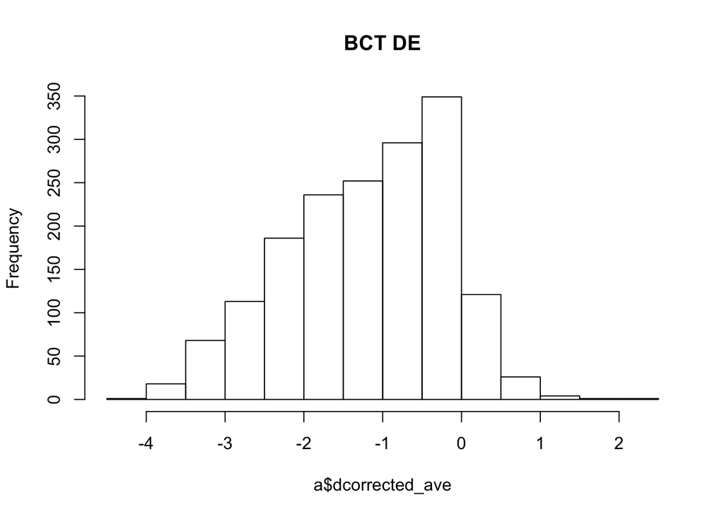

```r
a<- dcorrected_BCT %>% filter(., SeqName %in% expressiondat$SeqName) %>% ungroup() %>% select(.,dcorrected_ave)
hist(a$dcorrected_ave, main="BCT DE")
```

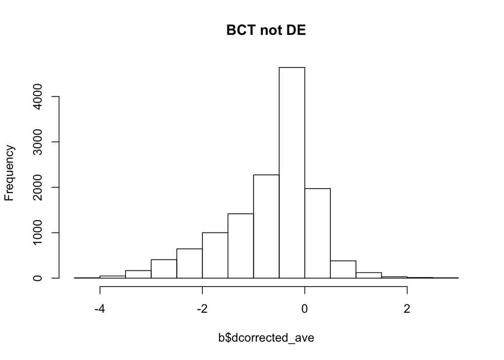

```r
b<-dcorrected_BCT %>% filter(., !SeqName %in% expressiondat$SeqName) %>% ungroup() %>% select(.,dcorrected_ave)
hist(b$dcorrected_ave,main="BCT not DE")
```

t-test Tajima’s D DE transcripts vs not DE transcripts: BCT

```r
t.test(a$dcorrected_ave,b$dcorrected_ave)
```

```
##
##  Welch Two Sample t-test
##
## data:  a$dcorrected_ave and b$dcorrected_ave
## t = -20.982, df = 2021, p-value < 2.2e-16
## alternative hypothesis: true difference in means is not equal to 0
## 95 percent confidence interval:
##  -0.5979277 -0.4957094
## sample estimates:
##  mean of x  mean of y
## -1.1886114 -0.6417929
```

WST: t-test

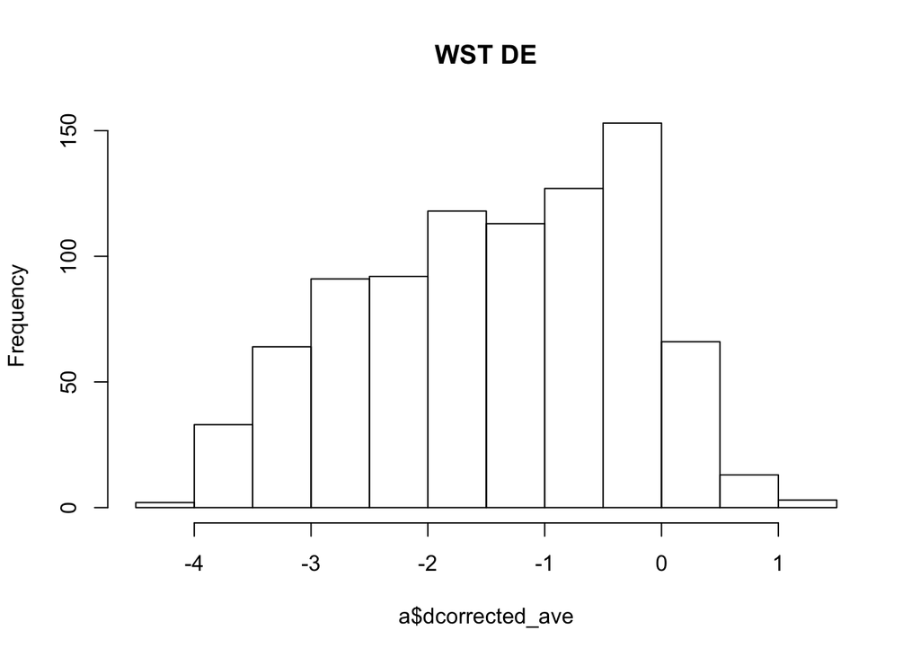

```r
a<- dcorrected_WST %>% filter(., SeqName %in% expressiondat$SeqName) %>% ungroup() %>% select(.,dcorrected_ave)
hist(a$dcorrected_ave,main="WST DE")
```

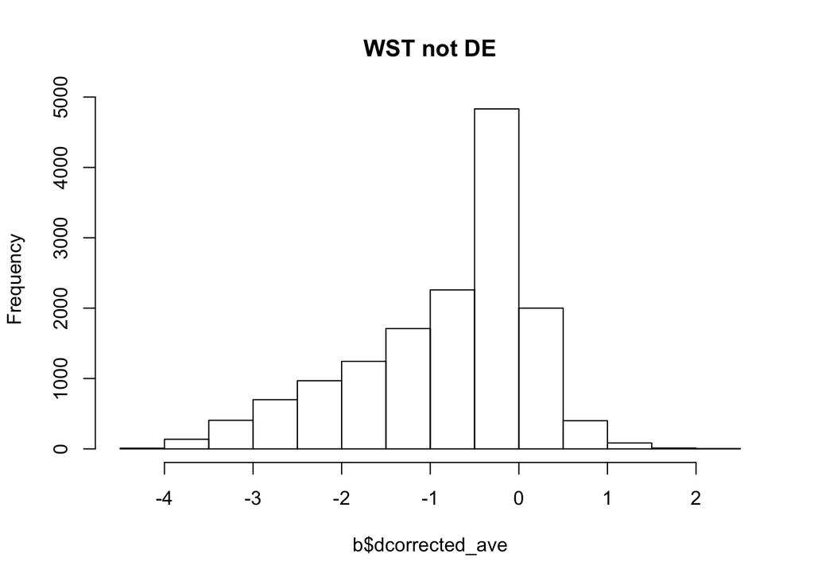

```r
b<-dcorrected_WST %>% filter(., !SeqName %in% expressiondat$SeqName) %>% ungroup() %>% select(.,dcorrected_ave)
hist(b$dcorrected_ave,main="WST not DE")
```

t-test Tajima’s D DE transcripts vs not DE transcripts: WST

```r
t.test(a$dcorrected_ave,b$dcorrected_ave)
```

```
##
##  Welch Two Sample t-test
##
## data:  a$dcorrected_ave and b$dcorrected_ave
## t = -15.42, df = 955.63, p-value < 2.2e-16
## alternative hypothesis: true difference in means is not equal to 0
## 95 percent confidence interval:
##  -0.6932628 -0.5367260
## sample estimates:
##  mean of x  mean of y
## -1.4221888 -0.8071944
```

# Question One: transcripts that were only differentially regulated in the White Sea (that’s the more freeze tolerant) population

```r
expressionWST<-read.csv("~/Documents/github/barnacles/allwsdiffreg.csv",header=T)

#average tajima D within BCT that are DE in only in white sea
dcorrected_BCT %>% filter(., SeqName %in% expressionWST$SeqName) %>% ungroup() %>% select(.,dcorrected_ave) %>% colMeans()
```

```
## dcorrected_ave
##      -1.189827
```

```r
#average tajima D within BCT that are NOT DE in only in white sea
dcorrected_BCT %>% filter(., !SeqName %in% expressionWST$SeqName) %>% ungroup() %>% select(.,dcorrected_ave) %>% colMeans()
```

```
## dcorrected_ave
##     -0.7021807
```

```r
#average tajima D within WST that are DE in only in white sea
dcorrected_WST %>% filter(., SeqName %in% expressionWST$SeqName) %>% ungroup() %>% select(.,dcorrected_ave) %>% colMeans()
```

```
## dcorrected_ave
##      -1.445604
```

```r
#average tajima D within WST that are NOT DE in only in white sea
dcorrected_WST %>% filter(., !SeqName %in% expressionWST$SeqName) %>% ungroup() %>% select(.,dcorrected_ave) %>% colMeans()
```

```
## dcorrected_ave
##     -0.8319091
```

BCT: t-test

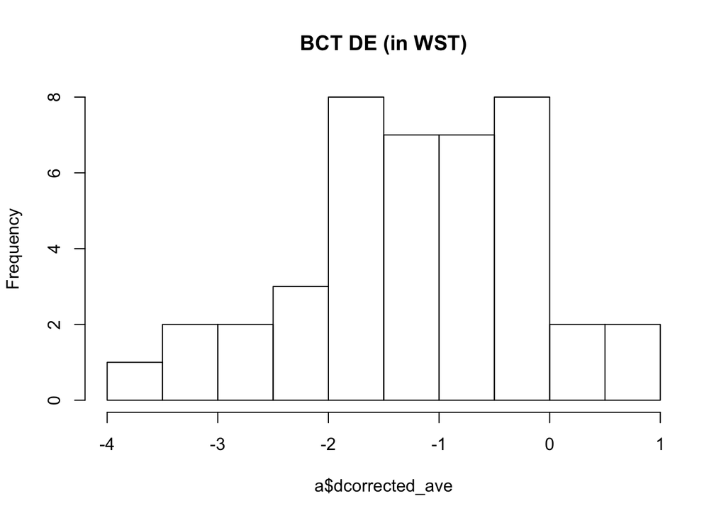

```r
a<- dcorrected_BCT %>% filter(., SeqName %in% expressionWST$SeqName) %>% ungroup() %>% select(.,dcorrected_ave)
hist(a$dcorrected_ave,main="BCT DE (in WST)")
```

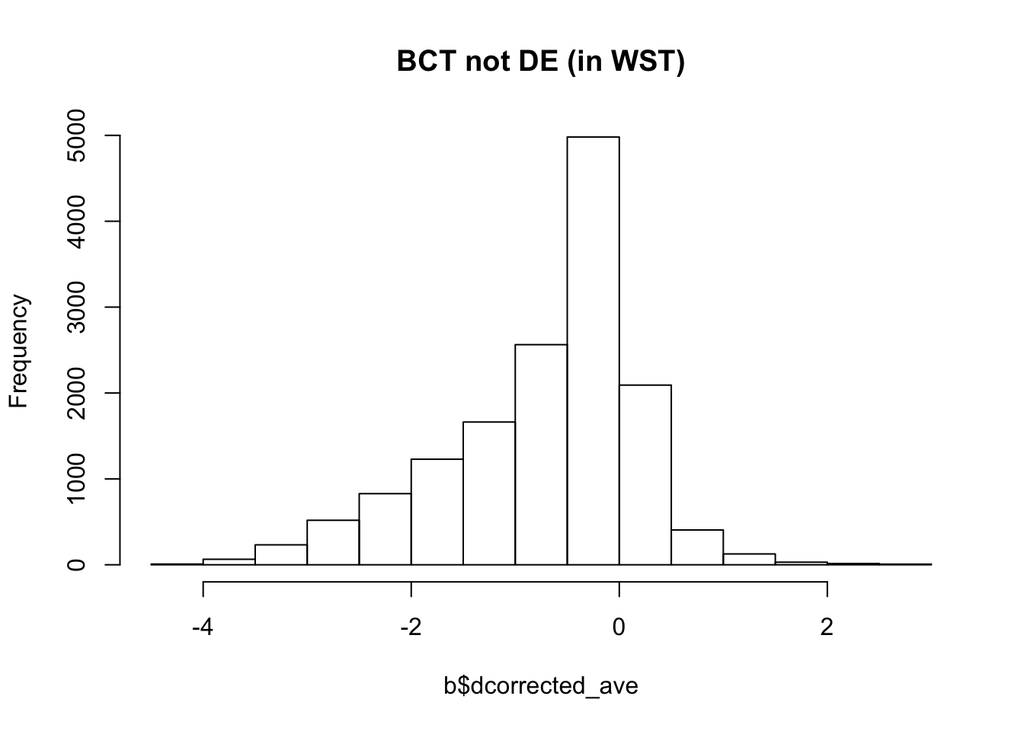

```r
b<-dcorrected_BCT %>% filter(., !SeqName %in% expressionWST$SeqName) %>% ungroup() %>% select(.,dcorrected_ave)
hist(b$dcorrected_ave,main="BCT not DE (in WST)")
```

t-test Tajima’s D DE transcripts in WST vs not DE transcripts in WST: BCT

```r
t.test(a$dcorrected_ave,b$dcorrected_ave)
```

```
##
##  Welch Two Sample t-test
##
## data:  a$dcorrected_ave and b$dcorrected_ave
## t = -2.9455, df = 41.176, p-value = 0.005284
## alternative hypothesis: true difference in means is not equal to 0
## 95 percent confidence interval:
##  -0.8219491 -0.1533430
## sample estimates:
##  mean of x  mean of y
## -1.1898267 -0.7021807
```

WST: t-test:

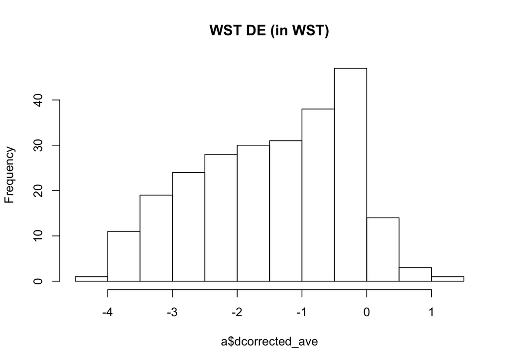

```r
a<- dcorrected_WST %>% filter(., SeqName %in% expressionWST$SeqName) %>% ungroup() %>% select(.,dcorrected_ave)
hist(a$dcorrected_ave,main="WST DE (in WST)")
```

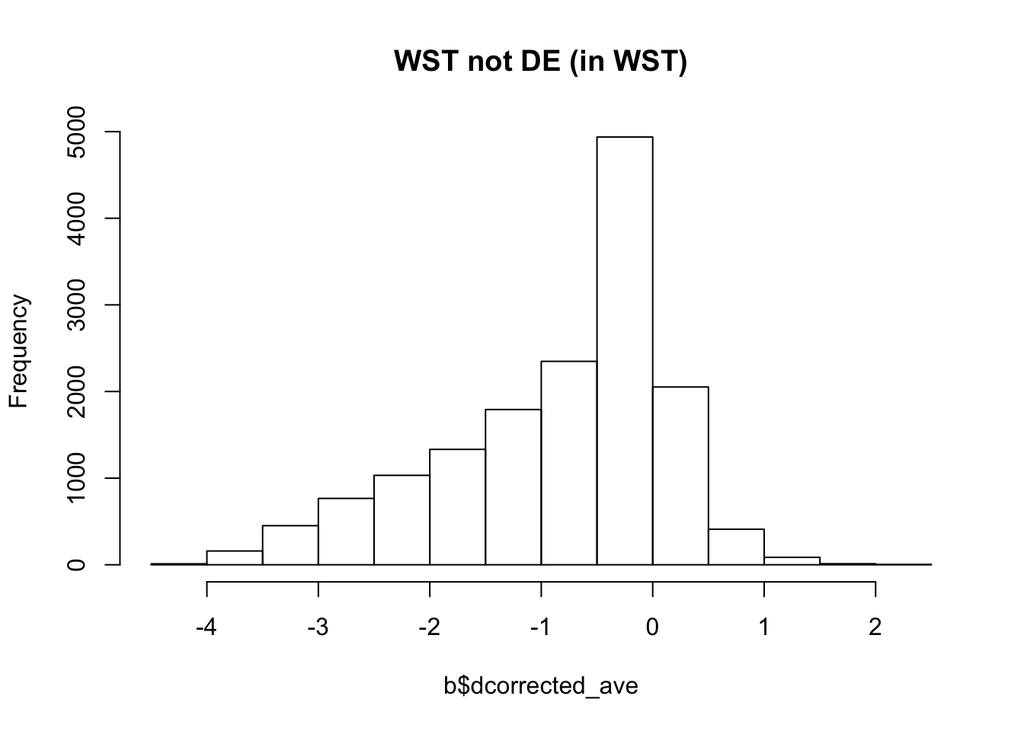

```r
b<-dcorrected_WST %>% filter(., !SeqName %in% expressionWST$SeqName) %>% ungroup() %>% select(.,dcorrected_ave)
hist(b$dcorrected_ave,main="WST not DE (in WST)")
```

t-test Tajima’s D DE transcripts in WST vs not DE transcripts in WST: WST

```r
t.test(a$dcorrected_ave,b$dcorrected_ave)
```

```
##
##  Welch Two Sample t-test
##
## data:  a$dcorrected_ave and b$dcorrected_ave
## t = -8.3487, df = 252.35, p-value = 4.594e-15
## alternative hypothesis: true difference in means is not equal to 0
## 95 percent confidence interval:
##  -0.7584620 -0.4689284
## sample estimates:
##  mean of x  mean of y
## -1.4456042 -0.8319091
```

# Question Two: Anything labelled with “transcription” as a function. I think these are likely transcription factors, and in particular, XLOC_006827 and XLOC_01766 are upregulated in both the BC and WS populations in the 4 hours following freezing

```r
expressionWST_transciption<-expressionWST %>% filter(.,grepl('transcription',InterPro.GO.Names) | grepl('transcription',GO.Names))

#average tajima D within BCT that are DE in only in white sea with a GO term of 'transciption'
dcorrected_BCT %>% filter(., SeqName %in% expressionWST_transciption$SeqName) %>% ungroup() %>% select(.,dcorrected_ave) %>% colMeans()
```

```
## dcorrected_ave
##      -1.157307
```

```r
#average tajima D within BCT that do not have a GO term of 'transciption'
dcorrected_BCT %>% filter(., !SeqName %in% expressionWST_transciption$SeqName) %>% ungroup() %>% select(.,dcorrected_ave) %>% colMeans()
```

```
## dcorrected_ave
##     -0.7035338
```

```r
#average tajima D within WST that are DE in only in white sea with a GO term of 'transciption'
dcorrected_WST %>% filter(., SeqName %in% expressionWST_transciption$SeqName) %>% ungroup() %>% select(.,dcorrected_ave) %>% colMeans()
```

```
## dcorrected_ave
##      -2.479258
```

```r
#average tajima D within WST that do not have a GO term of 'transciption'
dcorrected_WST %>% filter(., !SeqName %in% expressionWST_transciption$SeqName) %>% ungroup() %>% select(.,dcorrected_ave) %>% colMeans()
```

```
## dcorrected_ave
##     -0.8406581
```

There isnt enough of these transcipts in the BCT population for a t-test

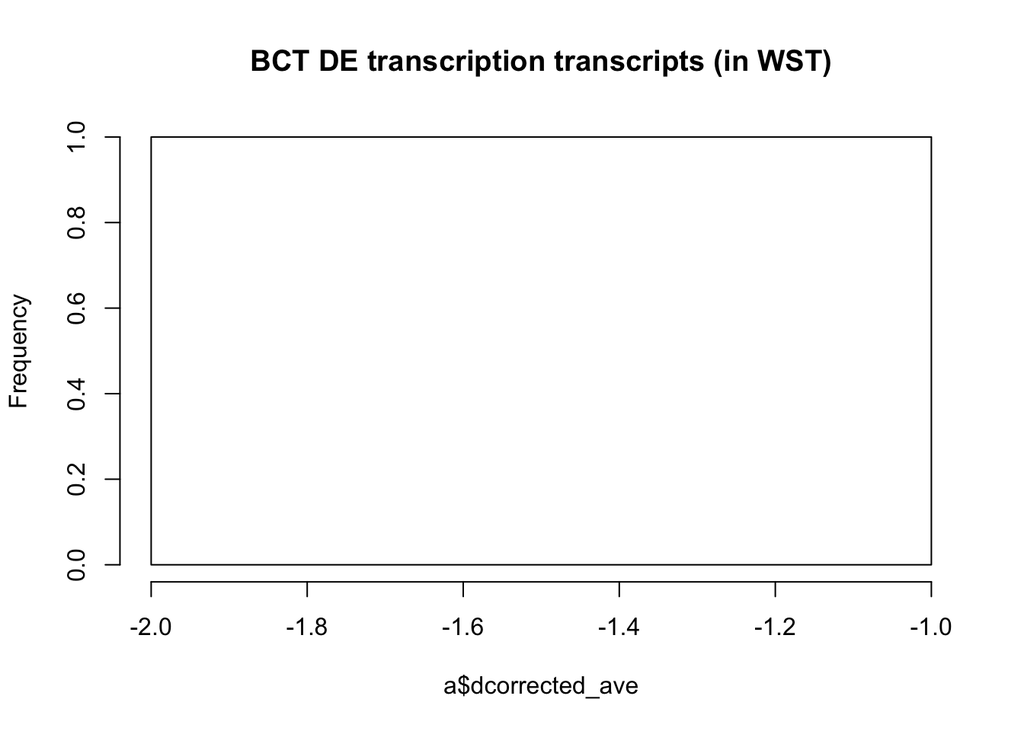

```r
a<- dcorrected_BCT %>% filter(., SeqName %in% expressionWST_transciption$SeqName) %>% ungroup() %>% select(.,dcorrected_ave)
hist(a$dcorrected_ave,main="BCT DE transcription transcripts (in WST)")
```

```r
nrow(a)
```

```
## [1] 1
```

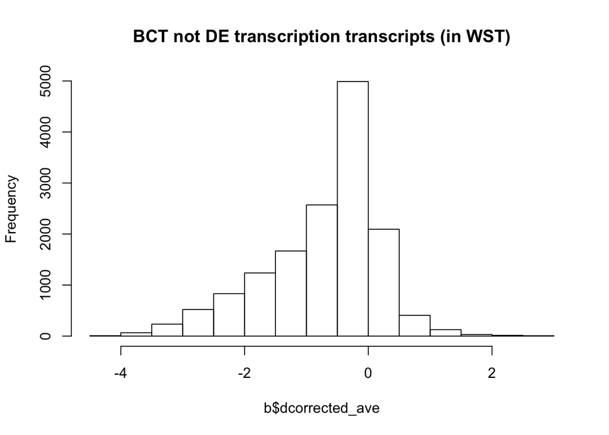

```r
b<-dcorrected_BCT %>% filter(., !SeqName %in% expressionWST_transciption$SeqName) %>% ungroup() %>% select(.,dcorrected_ave)
hist(b$dcorrected_ave,main="BCT not DE transcription transcripts (in WST)")
```

```r
nrow(b)
```

```
## [1] 14800
```

```r
#t.test(a$dcorrected_ave,b$dcorrected_ave)
```

WST: t-test:

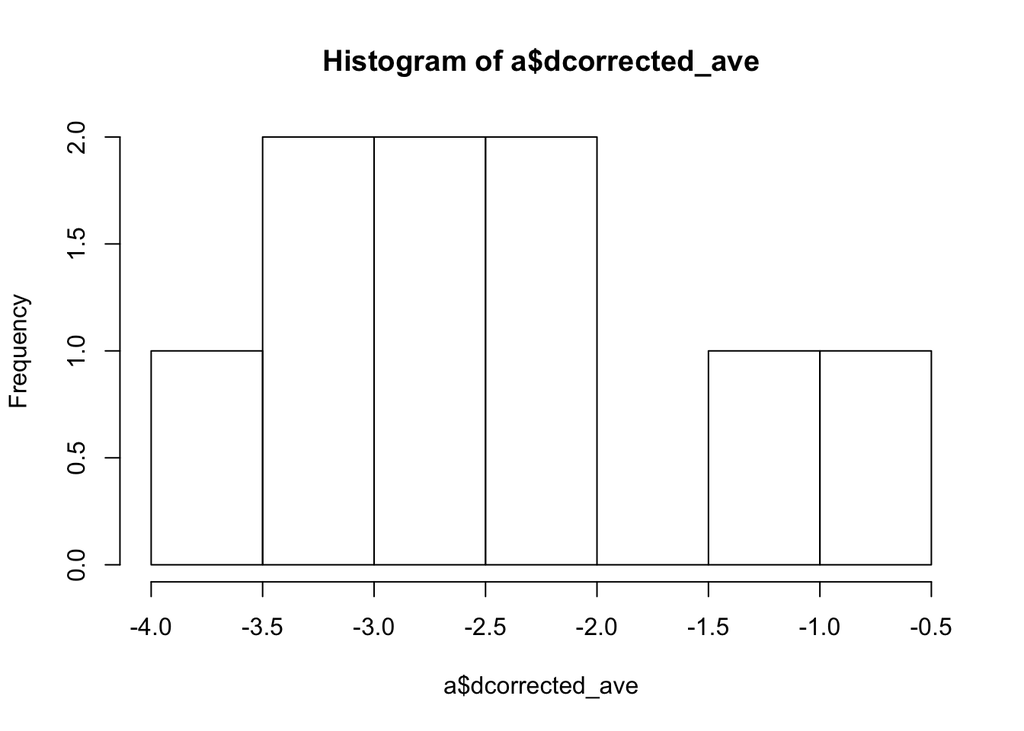

```r
a<- dcorrected_WST %>% filter(., SeqName %in% expressionWST_transciption$SeqName) %>% ungroup() %>% select(.,dcorrected_ave)
hist(a$dcorrected_ave)
```

```r
nrow(a)
```

```
## [1] 9
```

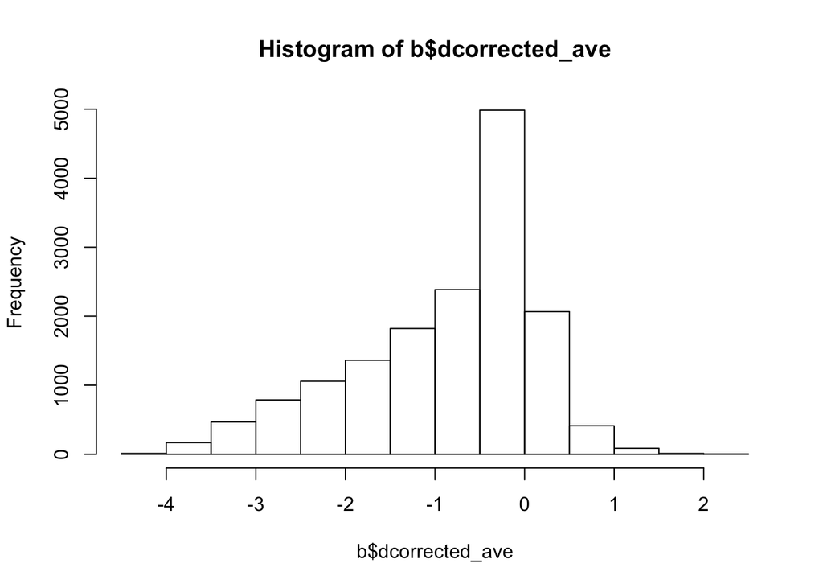

```r
b<-dcorrected_WST %>% filter(., !SeqName %in% expressionWST_transciption$SeqName) %>% ungroup() %>% select(.,dcorrected_ave)
hist(b$dcorrected_ave)
```

```r
nrow(b)
```

```
## [1] 15631
```

t-test Tajima’s D DE transcripts with transciption in GO term in WST vs not DE transcripts in WST: WST

```r
t.test(a$dcorrected_ave,b$dcorrected_ave)
```

```
##
##  Welch Two Sample t-test
##
## data:  a$dcorrected_ave and b$dcorrected_ave
## t = -5.6627, df = 8.013, p-value = 0.0004716
## alternative hypothesis: true difference in means is not equal to 0
## 95 percent confidence interval:
##  -2.3056946 -0.9715055
## sample estimates:
##  mean of x  mean of y
## -2.4792582 -0.8406581
```

# Question Three: Anything labelled as a potential aquaporin. (XLOC_019964, XLOC_019967, and XXLOC_035387 in particular)

Only three transcipts return from the search terms aquaporin or Aquaporin so not running t-tests

```r
expressionWST_aqua <-expressionWST %>% filter(.,grepl('aquaporin',Description)|grepl('Aquaporin',Description))

dcorrected_BCT %>% filter(., SeqName %in% expressionWST_aqua$SeqName) %>% ungroup() %>% select(.,dcorrected_ave) %>% colMeans()
```

```
## dcorrected_ave
##            NaN
```

```r
#no transcripts
#average tajima D within BCT that do not have a description of 'Aquaporin'
dcorrected_BCT %>% filter(., !SeqName %in% expressionWST_aqua$SeqName) %>% ungroup() %>% select(.,dcorrected_ave) %>% colMeans()
```

```
## dcorrected_ave
##     -0.7035645
```

```r
#average tajima D within WST that are DE in only in white sea with description of 'Aquaporin'
dcorrected_WST %>% filter(., SeqName %in% expressionWST_aqua$SeqName) %>% ungroup() %>% select(.,dcorrected_ave) %>% colMeans()
```

```
## dcorrected_ave
##      -2.604873
```

```r
#average tajima D within WST that do not have a description of 'Aquaporin'
dcorrected_WST %>% filter(., !SeqName %in% expressionWST_aqua$SeqName) %>% ungroup() %>% select(.,dcorrected_ave) %>% colMeans()
```

```
## dcorrected_ave
##     -0.8412628
```

# Question Four: Anything labelled as a “macrophage mannose receptor”. I think these are potentially novel antifreeze proteins–they often blast to fish Type 2 antifreeze proteins

```r
expressionWST_MMR <- expressionWST %>% filter(.,grepl('macrophage mannose receptor',Description))

#average tajima D within BCT that are DE in only in white sea with description of 'macrophage mannose receptor'
dcorrected_BCT %>% filter(., SeqName %in% expressionWST_MMR$SeqName) %>% ungroup() %>% select(.,dcorrected_ave) %>% colMeans()
```

```
## dcorrected_ave
##      -1.108875
```

```r
#average tajima D within BCT that do not have a description of 'macrophage mannose receptor'
dcorrected_BCT %>% filter(., !SeqName %in% expressionWST_MMR$SeqName) %>% ungroup() %>% select(.,dcorrected_ave) %>% colMeans()
```

```
## dcorrected_ave
##     -0.7035097
```

```r
#average tajima D within WST that are DE in only in white sea with description of 'macrophage mannose receptor'
dcorrected_WST %>% filter(., SeqName %in% expressionWST_MMR$SeqName) %>% ungroup() %>% select(.,dcorrected_ave) %>% colMeans()
```

```
## dcorrected_ave
##      -1.320399
```

```r
#average tajima D within WST that do not have a description of 'macrophage mannose receptor'
dcorrected_WST %>% filter(., !SeqName %in% expressionWST_MMR$SeqName) %>% ungroup() %>% select(.,dcorrected_ave) %>% colMeans()
```

```
## dcorrected_ave
##     -0.8414786
```

there isnt enough of the MMR transcripts to do t-tests

## FST

Bring in file interested. Here Fst: (change the # to switch to a stricter set)

```r
#fst<-read.table("~/Documents/Barnacles/notreat/popoolation/BCT_WST.max50000min10.fst",header=T)
fst<-read.table("~/Documents/Barnacles/notreat/popoolation/BCT_WST.max50000min50.fst",header=T)
```

Depends what you want to look at. If you have particular scaffolds that Just looking at the value of the top snp in a scaffold here just a rough look

```r
fst_top <- fst %>% group_by(.,SeqName) %>% slice(which.max(fst_values_BCT.WST))

fst_top %>% filter(., SeqName %in% expressiondat$SeqName) %>% ungroup() %>% select(.,fst_values_BCT.WST) %>% colMeans()
```

```
## fst_values_BCT.WST
##           0.960366
```

```r
fst_top %>% filter(., !SeqName %in% expressiondat$SeqName) %>% ungroup() %>% select(.,fst_values_BCT.WST) %>% colMeans()
```

```
## fst_values_BCT.WST
##          0.9480188
```

Not a lot going on the FST other than that they are really high

## FET

Seems to have the same problem as the FST they are just too different have to drop values that came in as Inf-less than ideal I think the tajimas D values are going to be most interesting as the differentiation is so high I think it just sweeps any signal out

```r
fet<-read.table("~/Documents/Barnacles/notreat/popoolation/BCT_WST.maxcov50000min10.fet",header=T)
#fet<-read.table("~/Documents/Barnacles/notreat/popoolation/BCT_WST.maxcov50000min50.fet",header=T)

fet_top <- fet %>% group_by(.,SeqName) %>% filter(., !fisher_values_.log10.p.value._BCT.WST==Inf) %>%  slice(which.max(fisher_values_.log10.p.value._BCT.WST))
fet_top %>% filter(., SeqName %in% expressiondat$SeqName) %>% ungroup() %>% select(.,fisher_values_.log10.p.value._BCT.WST) %>% colMeans()
```

```
## fisher_values_.log10.p.value._BCT.WST
##                              63.74633
```

```r
fet_top %>% filter(., !SeqName %in% expressiondat$SeqName) %>% ungroup() %>% select(.,fisher_values_.log10.p.value._BCT.WST) %>% colMeans()
```

```
## fisher_values_.log10.p.value._BCT.WST
##                              50.62169
```

There is also a program out recently that might be of interest: https://academic.oup.com/nar/article/44/19/e148/2468394